# Writing Functions in R (Chapter 5)

Robust Functions

Seun Odeyemi

2019-07-01

# Robust code

In the last chapter of the course you’ll learn how to write robust functions. Robust functions are easy to use because they are reliable: they either return the correct result or they fail with a clear error message. In this section you are going to learn about the problems that underlie these three function calls:

```r
df[, vars]
```

```
#> Error in eval(expr, envir, enclos): object 'vars' not found
```

```r
subset(df, x == y)
```

```
#> Error in subset.default(df, x == y): object 'x' not found
```

```r
data.frame(x = "a")
```

```
#>   x
#> 1 a
```

These calls look simple on the surface, but as you’ll learn, each of them have hidden deficiencies that can trip you up when you use them in a function. This problem arise because of a fundamental problem in R: R is both an environment for interactive data analysis(*helpful*) and a programming language (*strict*). When you are doing interactive analysis, you want to iterate as quickly as possible and you check each result as you go i.e. functions designed for interactive use can be helpful—it can guess what you want and if they guess wrong it’s no big deal. On the other hand, functions designed for programming should be robust. You are not working with them interactively so sometimes being helpful isn’t helpful. If a function tries to work with the input it’s given no matter how bad, it’s likely to cause problem later in the pipeline. You are then likely to get a confusing error message that doesn’t help with resolving the problem.

These potential problems will be covered in the following lesson and how you can avoid them in your own code. Before we jump into these problematic functions, we’ll start by learning how to have your functions throw informative error message instead of returning incorrect or surprising results.

## Throwing errors

```r
x <- 1:10

stopifnot(is.character(x))
# Error: is.character(x) is not TRUE
```

`stopifnot()` function is a quick way to throw an error message if a condition isn’t met. The argument to `stopifnot()` are logical expressions and if any are false an error is thrown. For example, if x is not a character vector, this code will throw an error. `stopifnot()` is great for adding quick checks to our function. The error messages that it generates is not that user-friendly. Using a conditional with a function stop is a more verbose alternative that allows you to specify a more helpful error message.

Here is a general pattern for using `stop()`: You subsitute a logical expression for condition and your own error message for error. It’s pretty similar to the way we use return. In certain circumstances, if the condition is true, exit the function early with a certain value except with stop instead of returning a value, we signal that a problem has occurred. The `call. = FALSE` argument shouldn’t be part of the error message. This is the setting we recommend for all errors. We can use that template to replace our `stopifnot()` call. Note that the condition is flipped between the two cases: for `stopifnot()` you describe what you want to be true and with `stop()` you describe what the problem is.

```r
if (condition) {
  stop("Error", call. = FALSE)
}

if (!is.character(x)) {
  stop("`x` should be a character vector", call. = FALSE)
}
# Error: `x` should be a character vector
```

# Practice I

1. An error is better than a surprise

Recall our `both_na()` function from Chapter 2, that finds the number of entries where vectors `x` and `y` both have missing values:

```r
both_na <- function(x, y){
  sum(is.na(x) & is.na(y))
}
```

We had an example where the behavior was a little surprising:

```r
x <- c(NA, NA, NA)
y <- c( 1, NA, NA, NA)
both_na(x, y)
```

The function works and returns `3`, but we certainly didn’t design this function with the idea that people could pass in different length arguments.

Using `stopifnot()` is a quick way to have your function stop, if a condition isn’t met. `stopifnot()` takes logical expressions as arguments and if any are `FALSE` an error will occur.

```r
# Define troublesome x and y
x <- c(NA, NA, NA)
y <- c( 1, NA, NA, NA)

both_na <- function(x, y) {
  # Add stopifnot() to check length of x and y
  stopifnot(length(x) == length(y))

  sum(is.na(x) & is.na(y))
}

# Call both_na() on x and y
both_na(x, y)
```

```
#> Error in both_na(x, y): length(x) == length(y) is not TRUE
```

2. An informative error is even better

Using `stop()` instead of `stopifnot()` allows you to specify a more informative error message. Recall the general pattern for using `stop()` is:

```r
if (condition) {
  stop("Error", call. = FALSE)
}
```

```
#> Error in eval(expr, envir, enclos): object 'condition' not found
```

Writing good error messages is an important part of writing a good function! We recommend your error tells the user what should be true, not what is false. For example, here a good error would be:

- `"x and y must have the same length"`, rather than the bad error
- `"x and y don't have the same length"`.

Let’s use this pattern to write a better check for the length of `x` and `y`.

```r
# Define troublesome x and y
x <- c(NA, NA, NA)
y <- c( 1, NA, NA, NA)

both_na <- function(x, y) {
  # Replace condition with logical
  if (length(x) != length(y)) {
    # Replace "Error" with better message
    stop("x and y must have the same length", call. = FALSE)
  }

  sum(is.na(x) & is.na(y))
}

# Call both_na()
both_na(x, y)
```

```
#> Error: x and y must have the same length
```

3. A different kind of surprise: side effects

Side effects describe the things that happen when you run a function that alters the state of your R session. If `foo()` is a function with no side effects (a.k.a. pure), then when we run `x <- foo()`, the only change we expect is that the variable x now has a new value. No other variables in the global environment should be changed or created, no output should be printed, no plots displayed, no files saved, no options changed. We know exactly the changes to the state of the session just by reading the call to the function.

Can you identify which of these functions doesn’t have side effects?

```r
show_missings <- function(x) {
  n <- sum(is.na(x))
  cat("Missing values: ", n, "\n", sep = "")
  x
}

# correct answer
replace_missings <- function(x, replacement) {
  x[is.na(x)] <- replacement
  x
}

plot_missings <- function(x) {
  plot(seq_along(x), is.na(x))
  x
}

exclude_missings <- function() {
  options(na.action = "na.exclude")
}
```

Correct, great job! Of course functions with side effects are crucial for data analysis. You need to be aware of them, and deliberate in their usage. It’s ok to use them if the side effect is desired, but don’t surprise users with unexpected side effects.

# Unstable Types

One class of functions that can lead to surprises are functions with return values that are of an unstable type. What does unstable type mean? It means the type of object returned from these functions can’t be predicted without knowing exactly what the inputs are. If a function returns a `dataframe` most of the time, but in certain circumstances it returns a `vector`, we say that function has an unstable type or it is *type-inconsistent*. Type inconsistent functions are really hard to program with because your code has to deal with a dataframe or vector output or explicitly handle the special cases.

Often you won’t realize you’ve used a type-inconsistent function inside your own functions until you call your function with slightly unusual input and the unexpected return type isn’t caught until you get a really weird error message three function calls later.

Let’s take a look at one really common call involving the `[ ]` subsetting of a `df`. If `df` is a `dataframe`, what’ll `df[1, ]` return? Your intution will probably to say: The first row of the dataframe, `df`. And 95% of the time you’ll be right. But if turns out be to a single column dataframe then, what you will get back is a `vector` with just the first value from the column in `df`. So, sometimes you get a dataframe sometimes you get a vector. This is a *type-inconsistent* function.

```r
# df is a dataframe with 4 columns
df <- data.frame(
  a = rnorm(10),
  b = rnorm(10),
  c = rnorm(10),
  d = rnorm(10)
)
df[1, ]
```

```
#>            a          b         c         d
#> 1 0.04901961 0.04506485 -1.982491 0.1587688
```

```r
# a single column dataframe
df <- data.frame(z = 1:3)
df[1, ]
```

```
#> [1] 1
```

In interactive use this is really not a problem. You know what df is and when you ask for the first row of df, if it’s a surprise you know about it immediately. Problems occur when you bury type-inconsistent function inside your own function.

Here is a really simple example. We’ve written a `last_row()` function that uses single [ ] to extract the last_row of a dataframe. We should expect this last_row() function to work for any dataframe input, but it suffers from the same type-inconsistency: if a user passes it a one-column dataframe, they don’t get back a one-row dataframe rather they get a length(1) vector. So, what to do? Unfortunately, the solution depends on the problem-causing function. In the [ ] subsetting case, there is actually an argument, `drop` that controls this behavior: setting `drop = FALSE` forces the [ ] subsetting to be type-consistent.

```r
# a type-inconsistent function
last_row <- function(df) {
  df[nrow(df), ]
}
df <- data.frame(x = 1:3)
# Not a row, just a vector
str(last_row(df))
```

```
#>  int 3
```

```r
# forcing type-consistency with drop
last_row <- function(df) {
  df[nrow(df), , drop = FALSE]
}
df <- data.frame(x = 1:3)
str(last_row(df))
```

```
#> 'data.frame':    1 obs. of  1 variable:
#>  $ x: int 3
```

In other situations it might more sense to subset a dataframe like a list: df[x] instead. Here, implementing the `drop = FALSE` solution results in a last row function that returns a one-row dataframe even in this case of a one-column dataframe.

In general, you should aim to have your functions to be type-stable. This makes your function easier for others to reason about. How do you avoid writing type-inconsistent functions?

- Learn the common type-inconsistent functions in R: `[, ]`, `sapply`
- Avoid using type-inconsistent functions inside your own functions.

Nothing using type-inconsistent function means you need to build a vocabulary of type-consistent functions to program with. All the functions in purrr are type-consistent and hopefully now you know why that’s an advantage.

# Practice II

1. sapply is another common culprit

`sapply()` is another common offender returning unstable types. The type of output from `sapply()` depends on the type of input.

Consider the following data frame and two calls to `sapply()`:

```r
df <- data.frame(
  a = 1L,
  b = 1.5,
  y = Sys.time(),
  z = ordered(1)
)

A <- sapply(df[1:4], class)
B <- sapply(df[3:4], class)
```

A will be a list, B will be a character matrix.

2. Using purrr solves the problem

This unpredictable behaviour is a sign that you shouldn’t rely on `sapply()` inside your own functions.

So, what do you do? Use alternate functions that are type consistent! And you already know a whole set: the `map()` functions in purrr.

In this example, when we call `class()` on the columns of the data frame we are expecting character output, so our function of choice should be: `map_chr()`:

```r
df <- data.frame(
  a = 1L,
  b = 1.5,
  y = Sys.time(),
  z = ordered(1)
)

A <- map_chr(df[1:4], class)
```

```
#> Result 3 must be a single string, not a character vector of length 2
```

```r
B <- map_chr(df[3:4], class)
```

```
#> Result 1 must be a single string, not a character vector of length 2
```

Except that gives us errors. This is a good thing! It alerts us that our assumption (that `class()` would return purely character output) is wrong.

Let’s look at a couple of solutions. First, we could use `map()` instead of `map_chr()`. Our result will always be a list, no matter the input.

```r
# sapply calls
A <- sapply(df[1:4], class)
B <- sapply(df[3:4], class)
C <- sapply(df[1:2], class)

# Demonstrate type inconsistency
str(A)
```

```
#> List of 4
#>  $ a: chr "integer"
#>  $ b: chr "numeric"
#>  $ y: chr [1:2] "POSIXct" "POSIXt"
#>  $ z: chr [1:2] "ordered" "factor"
```

```r
str(B)
```

```
#>  chr [1:2, 1:2] "POSIXct" "POSIXt" "ordered" "factor"
#>  - attr(*, "dimnames")=List of 2
#>   ..$ : NULL
#>   ..$ : chr [1:2] "y" "z"
```

```r
str(C)
```

```
#>  Named chr [1:2] "integer" "numeric"
#>  - attr(*, "names")= chr [1:2] "a" "b"
```

```r
# Use map() to define X, Y and Z
X <- map(df[1:4], class)
Y <- map(df[3:4], class)
Z <- map(df[1:2], class)

# Use str() to check type consistency
str(X)
```

```
#> List of 4
#>  $ a: chr "integer"
#>  $ b: chr "numeric"
#>  $ y: chr [1:2] "POSIXct" "POSIXt"
#>  $ z: chr [1:2] "ordered" "factor"
```

```r
str(Y)
```

```
#> List of 2
#>  $ y: chr [1:2] "POSIXct" "POSIXt"
#>  $ z: chr [1:2] "ordered" "factor"
```

```r
str(Z)
```

```
#> List of 2
#>  $ a: chr "integer"
#>  $ b: chr "numeric"
```

3. A type consistent solution

If we wrap our solution into a function, we can be confident that this function will always return a list because we’ve used a type consistent function, `map()`:

```r
col_classes <- function(df) {
  map(df, class)
}
```

But what if you wanted this function to always return a character string?

One option would be to decide what should happen if `class()` returns something longer than length 1. For example, we might simply take the first element of the vector returned by `class()`.

```r
col_classes <- function(df) {
  # Assign list output to class_list
  class_list <- map(df, class)

  # Use map_chr() to extract first element in class_list
  map_chr(class_list, 1)
}

# Check that our new function is type consistent
df %>% col_classes() %>% str()
```

```
#>  Named chr [1:4] "integer" "numeric" "POSIXct" "ordered"
#>  - attr(*, "names")= chr [1:4] "a" "b" "y" "z"
```

```r
df[3:4] %>% col_classes() %>% str()
```

```
#>  Named chr [1:2] "POSIXct" "ordered"
#>  - attr(*, "names")= chr [1:2] "y" "z"
```

```r
df[1:2] %>% col_classes() %>% str()
```

```
#>  Named chr [1:2] "integer" "numeric"
#>  - attr(*, "names")= chr [1:2] "a" "b"
```

4. Or fail early if something goes wrong

Another option would be to simply fail. We could rely on `map_chr()`’s type consistency to fail for us:

```r
col_classes <- function(df) {
  map_chr(df, class)
}

df %>% col_classes() %>% str()
```

```
#> Result 3 must be a single string, not a character vector of length 2
```

Or, check the condition ourselves and return an informative error message. We’ll implement this approach in this exercise.

As you write more functions, you’ll find you often come across this tension between implementing a function that does something sensible when something surprising happens, or simply fails when something surprising happens. Our recommendation is to fail when you are writing functions that you’ll use behind the scenes for programming and to do something sensible when writing functions for users to use interactively.

(And by the way, `flatten_chr()` is yet another useful function in `purrr`. It takes a list and removes its hierarchy. The `suffix _chr` indicates that this is another type consistent function, and will either return a character string or an error message.)

```r
col_classes <- function(df) {
  class_list <- map(df, class)

  # Add a check that no element of class_list has length > 1
  if (any(map_dbl(class_list, length) > 1)) {
    stop("Some columns have more than one class", call. = FALSE)
  }

  # Use flatten_chr() to return a character vector
  flatten_chr(class_list)
}

# Check that our new function is type consistent
df %>% col_classes() %>% str()
```

```
#> Error: Some columns have more than one class
```

```r
df[3:4] %>% col_classes() %>% str()
```

```
#> Error: Some columns have more than one class
```

```r
df[1:2] %>% col_classes() %>% str()
```

```
#>  chr [1:2] "integer" "numeric"
```

# Non-standard evaluation

Another class of functions that are a source of suprises when you use them in your own functions are those that use non-standard evaluation. Non-standard evaluation functions are functions which don’t use the usual lookup rules for variables. Let’s a look at a function you’ve probably already seen that uses non-standard evaluation, `subset()`.

```r
subset(mtcars, disp > 400)
```

```
#>                      mpg cyl disp  hp drat    wt  qsec vs am gear carb
#> Cadillac Fleetwood  10.4   8  472 205 2.93 5.250 17.98  0  0    3    4
#> Lincoln Continental 10.4   8  460 215 3.00 5.424 17.82  0  0    3    4
#> Chrysler Imperial   14.7   8  440 230 3.23 5.345 17.42  0  0    3    4
```

```r
disp > 400
```

```
#> Error in eval(expr, envir, enclos): object 'disp' not found
```

```r
disp
```

```
#> Error in eval(expr, envir, enclos): object 'disp' not found
```

In subset(), the first argument is a dataframe and the second is a logical expression that describe which rows of the dataframe to return. What is unusual about this logical expression is that it is evaluated inside a dataframe. Here `disp` is a column inside `mtcars` dataset. It doesn’t exist in the global environment and we can’t evaluate that logical expression in the global environment. Because subset() uses non-standard evaluation we can do away with the `$` we’ll normally need to refer to a column inside `mtcars`.

Non-standard evaluation functions are great for data analysis because they save a lot of typing, but when you use them inside your own function they can cause problems. Just like type-inconsistent functions, they’ll work most of the time, but a few special inputs can cause hard to track down problems.

Let’s take a look at other non-standard evaluation functions. The plotting functions in the `ggplot2` package also use non-standard evaluation. This is what allows us to specify aesthetic mappings without having to specify everything with a dataframe name and a `$` sign. Another package that use a lot of non-standard evaluation functions is `dplyr`. One example, the `filter()` function works a lot like the `subset()` function. The first argument is the dataframe, and the second argument is a logical expression that will be evaluated inside the dataframe.

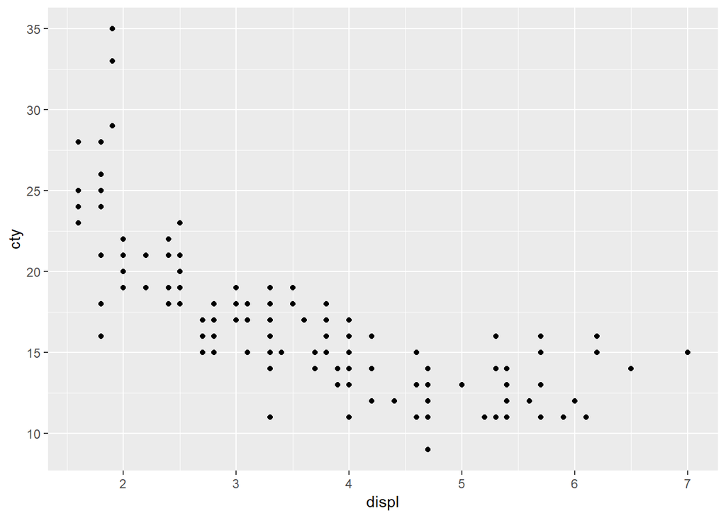

```r
library(ggplot2)
ggplot(mpg, aes(displ, cty)) + geom_point()
```

```r
library(dplyr)
filter(mtcars, disp > 400)
```

```
#>    mpg cyl disp  hp drat    wt  qsec vs am gear carb
#> 1 10.4   8  472 205 2.93 5.250 17.98  0  0    3    4
#> 2 10.4   8  460 215 3.00 5.424 17.82  0  0    3    4
#> 3 14.7   8  440 230 3.23 5.345 17.42  0  0    3    4
```

What gets tricky about these non-standard evaluation functions is that we can usually make reference to objects outside the dataframe as well. Take a look at the example below:

```r
disp_threshold <- 400
filter(mtcars, disp > disp_threshold)
```

```
#>    mpg cyl disp  hp drat    wt  qsec vs am gear carb
#> 1 10.4   8  472 205 2.93 5.250 17.98  0  0    3    4
#> 2 10.4   8  460 215 3.00 5.424 17.82  0  0    3    4
#> 3 14.7   8  440 230 3.23 5.345 17.42  0  0    3    4
```

Here, `disp` is a column inside the `mtcars` dataset. But `disp_threshold` is a object in the global environment. `filter()` does what we expect: it returns all rows where the value in the `disp` column is greater than 400, the value in `disp_threshold`. Whether the value for disp_threshold comes from the provider dataframe or from the global environment depends on whether the name can be found within the dataframe or not. This is what makes these functions tricky to program with. We aren’t going to know what is in the dataframe because it is probably an input to our function. This behavior is what you’ll explore in the following exercises.

## What to do?

Non-standard evaluation functions are great for interactive data analysis, they are another class of functions you might want to avoid when programming your own functions. You can use them with care, but you need to kinds of problems that occur and how to fix them. You’ll see some examples in the exercises. The good news is that this is still an area of development in R and programming with non-standard evaluation functions should be easier in the future.